# Data Exploration

Notebook for data exploration :

- Quick analyze of the entire dataset
- Specific analysis of the different features available

# 1. Imports

## 1.1 Packages

```python
import datetime
import os
import pandas as pd
import sys

import seaborn as sns
import matplotlib.pyplot as plt
import plotly.express as px

import statsmodels.api as sm
```

```python
sys.path.append("../src/")
from prepare_data import set_type
from feature_engineering import extract_date_features, add_lockdown_periods, add_holidays_period
```

## 1.2 Options

```python
%load_ext autoreload
%autoreload 2
```

```
The autoreload extension is already loaded. To reload it, use:
  %reload_ext autoreload
```

```python
path_data = '../data/raw/'

feat_date = "Date"
```

## 1.3 Datasets

```python
df = pd.read_csv(os.path.join(path_data, "dataset.gz"), sep=";")
df.sample(5)
```

|  | Date | Fourni | Ventes | id |
| --- | --- | --- | --- | --- |
| 68534 | 2022-08-31 | 14.0 | 7.0 | -7194905334837313370 |
| 27307 | 2020-12-12 | 10.0 | 7.0 | -876129535061941331 |
| 59163 | 2022-04-05 | 10.0 | 6.0 | -8817594176277759455 |
| 29459 | 2021-01-12 | 4.0 | 2.0 | 3847030529972014414 |
| 70361 | 2022-09-28 | 15.0 | 12.0 | -7760658437998414862 |

# 2. Analyze

```python
df = set_type(df, feat_date=feat_date)
```

## 2.1 Overall analysis

```python
print("Size of the dataset", df.shape)
```

```
Size of the dataset (83351, 4)
```

```python
# Description of the dataset
df.describe()
```

|  | Fourni | Ventes |
| --- | --- | --- |
| count | 83351.000000 | 83351.000000 |
| mean | 15.128697 | 10.173243 |
| std | 14.890796 | 12.016993 |
| min | 1.000000 | 0.000000 |
| 25% | 5.000000 | 2.000000 |
| 50% | 10.000000 | 6.000000 |
| 75% | 20.000000 | 14.000000 |
| max | 250.000000 | 227.000000 |

```python
# Number of unique values
for feat in df.columns:
    print(f'Number of unique values for feature {feat}:', df[feat].nunique())
```

```
Number of unique values for feature Date: 1192
Number of unique values for feature Fourni: 135
Number of unique values for feature Ventes: 129
Number of unique values for feature id: 100
```

```python
# Check the percentage of NaNs
df.isna().sum() / len(df)
```

```
Date      0.0
Fourni    0.0
Ventes    0.0
id        0.0
dtype: float64
```

## 2.2 Dates

```python
# Check the period of the dataset
df["Date"].describe(datetime_is_numeric=True)
```

```
count                            83351
mean     2021-07-27 00:11:56.276949248
min                2020-01-02 00:00:00
25%                2020-09-20 00:00:00
50%                2021-07-14 00:00:00
75%                2022-05-26 00:00:00
max                2023-04-17 00:00:00
Name: Date, dtype: object
```

```python
print("Number of unique dates:", df[feat_date].nunique())
```

```
Number of unique dates: 1192
```

```python
df[df["id"] == "-8929187383922749181"].head(20)
```

|  | Date | Fourni | Ventes | id |
| --- | --- | --- | --- | --- |
| 1 | 2020-01-02 | 8.0 | 1.0 | -8929187383922749181 |
| 101 | 2020-01-03 | 12.0 | 6.0 | -8929187383922749181 |
| 199 | 2020-01-04 | 26.0 | 12.0 | -8929187383922749181 |
| 296 | 2020-01-05 | 12.0 | 5.0 | -8929187383922749181 |
| 1705 | 2020-01-21 | 12.0 | 9.0 | -8929187383922749181 |
| 1797 | 2020-01-22 | 9.0 | 7.0 | -8929187383922749181 |
| 1883 | 2020-01-23 | 8.0 | 2.0 | -8929187383922749181 |
| 1978 | 2020-01-24 | 12.0 | 6.0 | -8929187383922749181 |
| 2072 | 2020-01-25 | 26.0 | 18.0 | -8929187383922749181 |
| 2165 | 2020-01-26 | 12.0 | 0.0 | -8929187383922749181 |
| 2321 | 2020-01-28 | 12.0 | 9.0 | -8929187383922749181 |
| 2414 | 2020-01-29 | 9.0 | 7.0 | -8929187383922749181 |
| 2500 | 2020-01-30 | 8.0 | 5.0 | -8929187383922749181 |
| 2598 | 2020-01-31 | 12.0 | 5.0 | -8929187383922749181 |
| 2696 | 2020-02-01 | 26.0 | 17.0 | -8929187383922749181 |
| 2792 | 2020-02-02 | 12.0 | 3.0 | -8929187383922749181 |
| 2953 | 2020-02-04 | 24.0 | 21.0 | -8929187383922749181 |
| 3046 | 2020-02-05 | 18.0 | 17.0 | -8929187383922749181 |
| 3133 | 2020-02-06 | 16.0 | 15.0 | -8929187383922749181 |
| 3231 | 2020-02-07 | 24.0 | 19.0 | -8929187383922749181 |

## 2.3 Analyze by Id

Ids might represent each specific selling points. So we analyze the spread of the data by selling point

```python
print("The number of unique stores is:", df["id"].nunique())
```

```
The number of unique stores is: 100
```

```python
df_id = df["id"].value_counts().reset_index(drop=False)
df_id.columns=["id", "count"]
df_id["id"] = df_id["id"].astype(str)
```

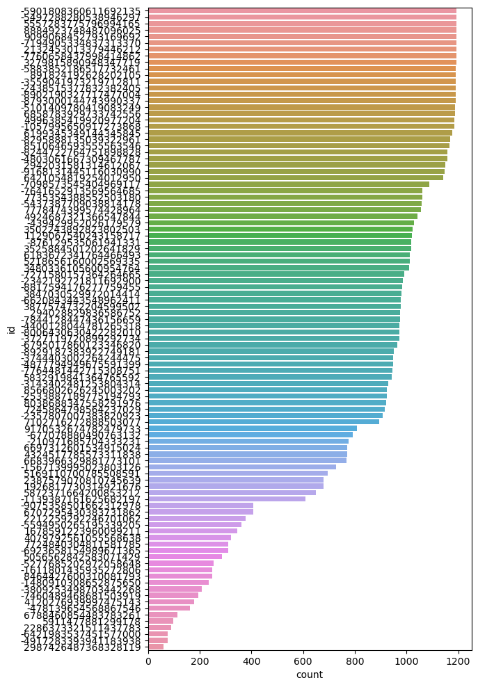

```python
_, ax = plt.subplots(figsize=(6, 12))
sns.barplot(data=df_id, x='count', y='id', ax=ax)
```

As we can see, some point of sales are less represented in the dataset than others. We check the dates available in the data to understand why:

```python
id_less = df_id.iloc[-1]["id"]
df[df["id"] == id_less]
```

|  | Date | Fourni | Ventes | id |
| --- | --- | --- | --- | --- |
| 46 | 2020-01-02 | 9.0 | 4.0 | 2987426487368328119 |
| 145 | 2020-01-03 | 10.0 | 4.0 | 2987426487368328119 |
| 242 | 2020-01-04 | 10.0 | 2.0 | 2987426487368328119 |
| 327 | 2020-01-05 | 13.0 | 5.0 | 2987426487368328119 |
| 410 | 2020-01-06 | 10.0 | 5.0 | 2987426487368328119 |
| 500 | 2020-01-07 | 10.0 | 6.0 | 2987426487368328119 |
| 589 | 2020-01-08 | 11.0 | 4.0 | 2987426487368328119 |
| 679 | 2020-01-09 | 9.0 | 3.0 | 2987426487368328119 |
| 776 | 2020-01-10 | 10.0 | 3.0 | 2987426487368328119 |
| 871 | 2020-01-11 | 10.0 | 5.0 | 2987426487368328119 |
| 954 | 2020-01-12 | 13.0 | 3.0 | 2987426487368328119 |
| 1035 | 2020-01-13 | 10.0 | 5.0 | 2987426487368328119 |
| 1124 | 2020-01-14 | 10.0 | 4.0 | 2987426487368328119 |
| 1212 | 2020-01-15 | 11.0 | 4.0 | 2987426487368328119 |
| 1303 | 2020-01-16 | 9.0 | 3.0 | 2987426487368328119 |
| 1399 | 2020-01-17 | 10.0 | 4.0 | 2987426487368328119 |
| 1494 | 2020-01-18 | 10.0 | 6.0 | 2987426487368328119 |
| 1576 | 2020-01-19 | 13.0 | 4.0 | 2987426487368328119 |
| 1659 | 2020-01-20 | 10.0 | 3.0 | 2987426487368328119 |
| 1748 | 2020-01-21 | 10.0 | 4.0 | 2987426487368328119 |
| 1836 | 2020-01-22 | 11.0 | 2.0 | 2987426487368328119 |
| 1925 | 2020-01-23 | 9.0 | 7.0 | 2987426487368328119 |
| 2019 | 2020-01-24 | 10.0 | 4.0 | 2987426487368328119 |
| 2113 | 2020-01-25 | 10.0 | 5.0 | 2987426487368328119 |
| 2194 | 2020-01-26 | 13.0 | 1.0 | 2987426487368328119 |
| 2275 | 2020-01-27 | 10.0 | 2.0 | 2987426487368328119 |
| 2364 | 2020-01-28 | 10.0 | 6.0 | 2987426487368328119 |
| 2453 | 2020-01-29 | 11.0 | 6.0 | 2987426487368328119 |
| 2544 | 2020-01-30 | 9.0 | 3.0 | 2987426487368328119 |
| 2642 | 2020-01-31 | 10.0 | 6.0 | 2987426487368328119 |
| 2739 | 2020-02-01 | 10.0 | 6.0 | 2987426487368328119 |
| 2823 | 2020-02-02 | 13.0 | 2.0 | 2987426487368328119 |
| 2906 | 2020-02-03 | 10.0 | 0.0 | 2987426487368328119 |
| 2997 | 2020-02-04 | 20.0 | 16.0 | 2987426487368328119 |
| 3086 | 2020-02-05 | 22.0 | 16.0 | 2987426487368328119 |
| 3178 | 2020-02-06 | 18.0 | 16.0 | 2987426487368328119 |
| 3275 | 2020-02-07 | 20.0 | 15.0 | 2987426487368328119 |
| 3371 | 2020-02-08 | 10.0 | 0.0 | 2987426487368328119 |
| 3454 | 2020-02-09 | 13.0 | 4.0 | 2987426487368328119 |
| 3536 | 2020-02-10 | 10.0 | 3.0 | 2987426487368328119 |
| 3624 | 2020-02-11 | 16.0 | 13.0 | 2987426487368328119 |
| 3711 | 2020-02-12 | 16.0 | 14.0 | 2987426487368328119 |
| 3801 | 2020-02-13 | 16.0 | 13.0 | 2987426487368328119 |
| 3896 | 2020-02-14 | 16.0 | 12.0 | 2987426487368328119 |
| 3990 | 2020-02-15 | 16.0 | 11.0 | 2987426487368328119 |
| 4147 | 2020-02-17 | 16.0 | 11.0 | 2987426487368328119 |
| 4231 | 2020-02-18 | 16.0 | 12.0 | 2987426487368328119 |
| 4313 | 2020-02-19 | 16.0 | 12.0 | 2987426487368328119 |
| 4398 | 2020-02-20 | 8.0 | 6.0 | 2987426487368328119 |
| 4486 | 2020-02-21 | 8.0 | 4.0 | 2987426487368328119 |
| 4574 | 2020-02-22 | 8.0 | 6.0 | 2987426487368328119 |
| 4726 | 2020-02-24 | 8.0 | 3.0 | 2987426487368328119 |
| 4812 | 2020-02-25 | 8.0 | 3.0 | 2987426487368328119 |
| 4897 | 2020-02-26 | 8.0 | 5.0 | 2987426487368328119 |
| 4988 | 2020-02-27 | 8.0 | 6.0 | 2987426487368328119 |
| 5083 | 2020-02-28 | 8.0 | 6.0 | 2987426487368328119 |
| 5177 | 2020-02-29 | 8.0 | 8.0 | 2987426487368328119 |
| 5516 | 2020-03-04 | 8.0 | 8.0 | 2987426487368328119 |
| 5608 | 2020-03-05 | 8.0 | 0.0 | 2987426487368328119 |

As we can see, this point of sell closed just before covid and never opened after. On the contrary, some ids have 1192 rows which correspond to the number of unique dates so they were opened during the all period covered by the dataset.

We get some info from the date feature

```python
df = df.pipe(extract_date_features, feat_date=feat_date)\
    .pipe(add_lockdown_periods, feat_date=feat_date)\
    .pipe(add_holidays_period, feat_date=feat_date, zone="Zone A")\
    .pipe(add_holidays_period, feat_date=feat_date, zone="Zone B")\
    .pipe(add_holidays_period, feat_date=feat_date, zone="Zone C")
```

```python
# Check the influence of the weekend
df.groupby(f"{feat_date}_weekend")["Ventes"].mean()
```

```
Date_weekend
0     8.828622
1    13.832440
Name: Ventes, dtype: float64
```

```python
# Check the influence of the weekday
df.groupby(f"{feat_date}_weekday")["Ventes"].mean()
```

```
Date_weekday
0     9.558567
1     8.801954
2     8.436226
3     8.762616
4     8.637141
5    15.294355
6    11.941845
Name: Ventes, dtype: float64
```

On average, the number of sales is greater during weekend, and more precisely on Saturday.

```python
# Check the influence of the month
df.groupby(f"{feat_date}_month")["Ventes"].mean()
```

```
Date_month
1      9.974519
2     11.423368
3     10.053332
4     10.678943
5     10.441460
6      9.892739
7      9.935827
8     10.429542
9      9.429382
10     9.718072
11     9.930351
12     9.930900
Name: Ventes, dtype: float64
```

On average, the daily sales per month is quite constant, with a small peak during february.

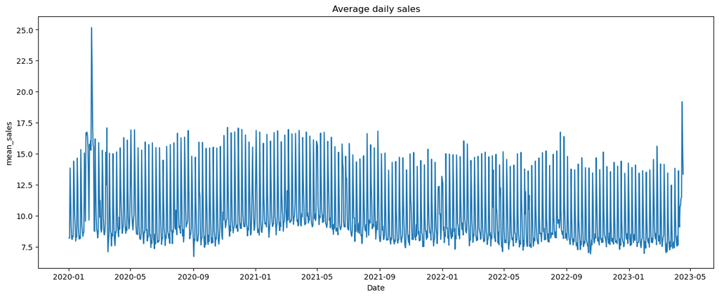

```python
df_mean_by_date = df.groupby(feat_date)["Ventes"].mean().reset_index(drop=False)
df_mean_by_date.columns = ["Date", "mean_sales"]

_, ax = plt.subplots(figsize=(16, 6))
ax.set_title("Average daily sales")
sns.lineplot(data=df_mean_by_date, x="Date", y="mean_sales", ax=ax)
plt.show()
```

We can see that the overall tendency of the daily sales is decreasing with a peak in february 2020.

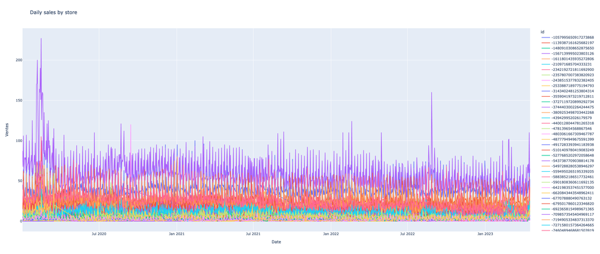

```python
px.line(df.sort_values(["id", feat_date]), x=feat_date, y="Ventes", color='id', title = "Daily sales by store", height=900)
```

Some stores have higher daily sales in average than others

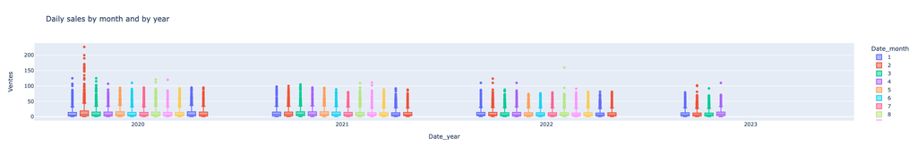

```python
px.box(df, x=f"{feat_date}_year", y="Ventes" , color=f"{feat_date}_month", title="Daily sales by month and by year")
```

The peak is confirmed in february 2020. This might be explained by the spread of the covid at this period.

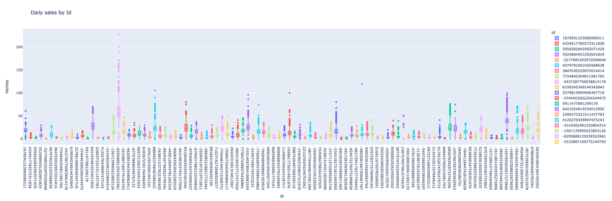

```python
px.box(df, x=f"id", y="Ventes" , color=f"id", title="Daily sales by Id", height=700)
```

As we can see, one store has higher sales than the others. We check the top 10 sellers to see their behavior

```python
list_top10_sellers = df.sort_values(by="Ventes", ascending=False).drop_duplicates(subset="id").iloc[:10]["id"]
list_top10_sellers
```

```
3996     -8295888135039322961
20322    -4803061667309467787
3991      8884923748487096025
4169      1926817730314921676
31729    -1057995650917273868
4018     -5101409780419083249
3960     -2342192721811692900
28728     8510646593555563546
10037     6858783929733742556
2733     -2357807007383820923
Name: id, dtype: object
```

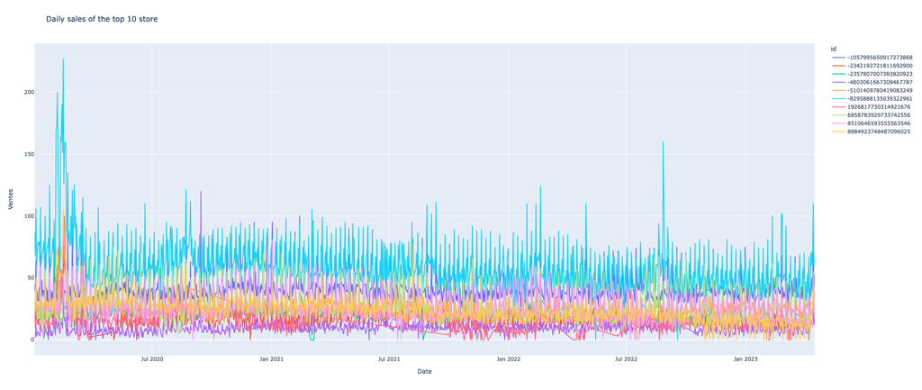

```python
px.line(df[df["id"].isin(list_top10_sellers)].sort_values(["id", feat_date]), x=feat_date, y="Ventes", color='id', title = "Daily sales of the top 10 store", height=900)
```

For the top sale store, we see 3 big peaks on February 6th and 15th, and August 27th for the top seller. We also see a peak on Sept, 14th for id -4803061667309467787.

Let's check around theses dates the number of sales and and newspapers delivered.

```python
dates_peak = [
    datetime.date(2020, 2, 5), datetime.date(2020, 2, 6), datetime.date(2020, 2, 7),
    datetime.date(2020, 2, 14), datetime.date(2020, 2, 15), datetime.date(2020, 2, 16),
    datetime.date(2022, 8, 26), datetime.date(2022, 8, 27), datetime.date(2022, 8, 29)
]
df[(df["id"] == list_top10_sellers.values[0]) & (df[feat_date].isin(dates_peak))]
```

|  | Date | Fourni | Ventes | id | Date_year | Date_month | Date_day | Date_weekday | Date_weekend | lockdown | Description_ZoneA | Description_ZoneB | Description_ZoneC |
| --- | --- | --- | --- | --- | --- | --- | --- | --- | --- | --- | --- | --- | --- |
| 3093 | 2020-02-05 | 180.0 | 171.0 | -8295888135039322961 | 2020 | 2 | 5 | 2 | 0 | 0 | None | None | None |
| 3185 | 2020-02-06 | 200.0 | 200.0 | -8295888135039322961 | 2020 | 2 | 6 | 3 | 0 | 0 | None | None | None |
| 3282 | 2020-02-07 | 160.0 | 147.0 | -8295888135039322961 | 2020 | 2 | 7 | 4 | 0 | 0 | None | None | None |
| 3903 | 2020-02-14 | 160.0 | 151.0 | -8295888135039322961 | 2020 | 2 | 14 | 4 | 0 | 0 | None | None | Vacances d'Hiver |
| 3996 | 2020-02-15 | 250.0 | 227.0 | -8295888135039322961 | 2020 | 2 | 15 | 5 | 1 | 0 | None | Vacances d'Hiver | Vacances d'Hiver |
| 4075 | 2020-02-16 | 150.0 | 126.0 | -8295888135039322961 | 2020 | 2 | 16 | 6 | 1 | 0 | None | Vacances d'Hiver | Vacances d'Hiver |
| 68229 | 2022-08-26 | 85.0 | 57.0 | -8295888135039322961 | 2022 | 8 | 26 | 4 | 0 | 0 | Vacances d'Été | Vacances d'Été | Vacances d'Été |
| 68291 | 2022-08-27 | 160.0 | 160.0 | -8295888135039322961 | 2022 | 8 | 27 | 5 | 1 | 0 | Vacances d'Été | Vacances d'Été | Vacances d'Été |
| 68396 | 2022-08-29 | 95.0 | 73.0 | -8295888135039322961 | 2022 | 8 | 29 | 0 | 0 | 0 | Vacances d'Été | Vacances d'Été | Vacances d'Été |

```python
dates_peak = [
    datetime.date(2020, 9, 11), datetime.date(2020, 9, 12),
    datetime.date(2020, 9, 13), datetime.date(2020, 9, 14), datetime.date(2020, 9, 15),
    datetime.date(2020, 9, 16), datetime.date(2020, 9, 17),
]
df[(df["id"] == "-4803061667309467787") & (df[feat_date].isin(dates_peak))]
```

|  | Date | Fourni | Ventes | id | Date_year | Date_month | Date_day | Date_weekday | Date_weekend | lockdown | Description_ZoneA | Description_ZoneB | Description_ZoneC |
| --- | --- | --- | --- | --- | --- | --- | --- | --- | --- | --- | --- | --- | --- |
| 20097 | 2020-09-11 | 15.0 | 15.0 | -4803061667309467787 | 2020 | 9 | 11 | 4 | 0 | 0 | None | None | None |
| 20181 | 2020-09-12 | 25.0 | 16.0 | -4803061667309467787 | 2020 | 9 | 12 | 5 | 1 | 0 | None | None | None |
| 20257 | 2020-09-13 | 25.0 | 10.0 | -4803061667309467787 | 2020 | 9 | 13 | 6 | 1 | 0 | None | None | None |
| 20322 | 2020-09-14 | 120.0 | 120.0 | -4803061667309467787 | 2020 | 9 | 14 | 0 | 0 | 0 | None | None | None |
| 20395 | 2020-09-15 | 20.0 | 9.0 | -4803061667309467787 | 2020 | 9 | 15 | 1 | 0 | 0 | None | None | None |
| 20476 | 2020-09-16 | 20.0 | 6.0 | -4803061667309467787 | 2020 | 9 | 16 | 2 | 0 | 0 | None | None | None |
| 20551 | 2020-09-17 | 20.0 | 7.0 | -4803061667309467787 | 2020 | 9 | 17 | 3 | 0 | 0 | None | None | None |

Nothing seems to indicate a big sell for this specific day of September 14th. This might be explained by the news.

## 2.4 Add features

```python
df = extract_date_features(df, feat_date)
df = add_lockdown_periods(df, feat_date)
```

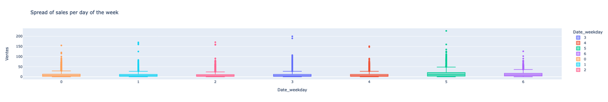

```python
px.box(df, x=f"{feat_date}_weekday", y="Ventes" , color=f"{feat_date}_weekday", title="Spread of sales per day of the week")
```

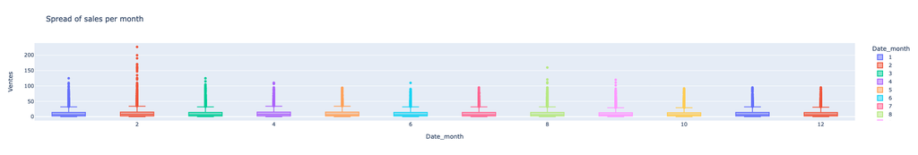

```python
px.box(df, x=f"{feat_date}_month", y="Ventes" , color=f"{feat_date}_month", title="Spread of sales per month")
```

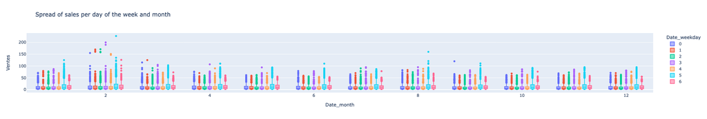

```python
px.box(
    df.sort_values(by=[f"{feat_date}_month", f"{feat_date}_weekday"]), x=f"{feat_date}_month", y="Ventes" ,
    color=f"{feat_date}_weekday", title="Spread of sales per day of the week and month"
)
```

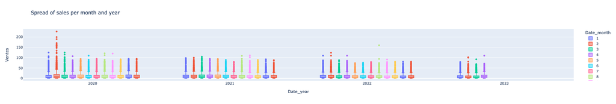

```python
px.box(df, x=f"{feat_date}_year", y="Ventes" , color=f"{feat_date}_month", title="Spread of sales per month and year")
```

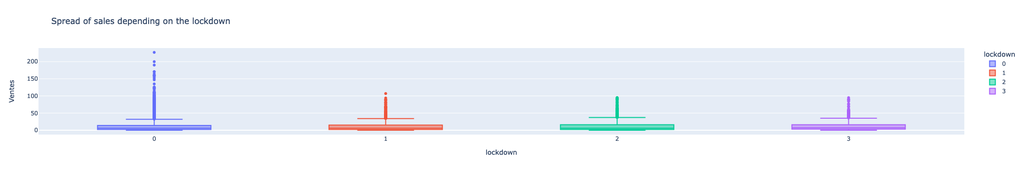

```python
px.box(df, x="lockdown", y="Ventes" , color="lockdown", title="Spread of sales depending on the lockdown")
```